# Modeling quality of suggestions

###### Ref. ↓

Plotting are under curve for various models:

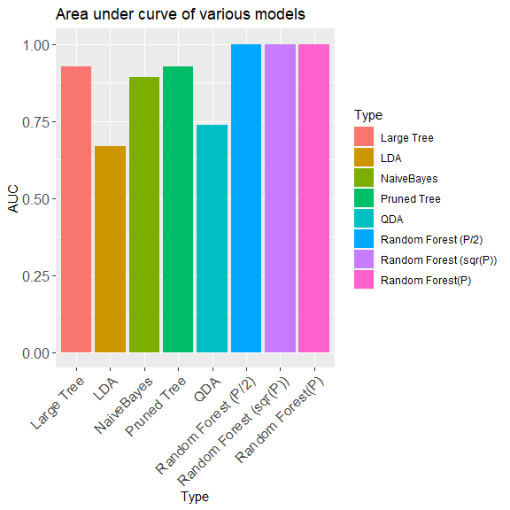

```r
hrdata.auc.df <- data.frame("Type" = c("Large Tree", "Pruned Tree", "Random Forest(P)", "Random Forest (P/2)", "Random Forest (sqr(P))", "NaiveBayes", "LDA", "QDA"), "AUC" = c(auc(hrdata.large.tree.roc), auc(hrdata.pruned.tree.roc), auc(hrdata.rf1.roc), auc(hrdata.rf2.roc), auc(hrdata.rf3.roc), auc(hrdata.nb.roc), auc(hrdata.lda.roc), auc(hrdata.qda.roc)))

ggplot(data = hrdata.auc.df) + geom_bar(mapping = aes(x = Type, y = AUC, fill = Type),  position = "dodge", stat = "identity") + ggtitle("Area under curve of various models") + theme(axis.text=element_text(size=12), axis.text.x = element_text(angle = 45, hjust = 1))
```

## Section 5: Conclusion

We had some initial questions the gist of which we used as a framework to establish path for data analysis for this report. We will attempt to answer those questions based on our analysis:

**1a.** Determine which combination of attributes of the suggestion (and maybe the person who wrote it) can be used to predict a ‘good’ suggestion.

These in order mattered most then predicting a “good” suggestion when compared to other predictors. We dropped the author_id & suggestion_id column before applying the predictor selection function(s).

**1b.** Does number of views matter more or less than votes?

**Answer:** # of downvotes & responses to a post actually mattered more than views.

**2a.** How much does the ‘age’ of the employee matter when it comes to their ability to make a good suggestion?

**2b.** Are the employees with longer tenures making better suggestions than those with shorter ones?

**Answer:** There was indeed higher distribution of good recommendations from profile with bigger age value according the density plot. On lower ages profiles however, the distinction was less important.

**3a.** Can the same data be used to rank employees based on their demonstrated ability to make predominantly good suggestions?

**Answer:** There were slightly varying order of suggested predictors when grouping the posts made by each authors. For each author, more recommended posts generally tended to come from the ones who had higher “author_profile_age”, “author_posts_per_day” and “responsesiveness” (views/responses). We did not penalize high number of posts with less views or recommendation on this analysis so the model could be slightly biased towards # of “author_posts_per_day” were an author post a lot of posts just because some of them could get responses and less downvotes making them a recommended suggestion. With this analysis we could create a scoring function that creates a sorting index based on higher values of “author_profile_age”, “author_posts_per_day” & “responsiveness” combined to create a ranking function of author who are likely to post more recommended posts.

**3b.** Can it be used to identify groups of employees whose suggestions could be aggregated to provide more reliable suggestions than made by the best individuals?

**Answer:** As per the previous question, grouping employees with bigger age profile & # of posts did seem to group the employees who could provide more reliable suggestions. If we were to remove the time element & # of posts out of the analysis, the # of downvotes & responsiveness interaciton term (responses/views) seem to matter the most. So even new profiles as long as their posts have less downvotes & have more responsiveness (response/views) are more likely to be recommended posts.

**4a.** Make recommendations to your IT department about better ways they could collect this data in the future. What other attributes would prove useful and why? Would it be possible to build a completely automated suggestion ranking system?

**Answer:** There was high prediction rate for each posts, however less attributes when we dropeed un-necessary predictors for analyzing posts by author_id. Information about author_id such as their real-life age or position of the employee, salary could potentially provide more features that provides insight into author profiles making high recommended suggestion so I would suggest the IT department to collect such data.